# Introduction to Neural Networks (Lecture Edition)

Table of Contents

1. Modeling image and text data Some challenging unsolved biomedical problems A. Anomaly detection B. Modeling EHR data for prognosis prediction Why neural networks? Why not neural networks? 2. Neural network primer The anatomy of a neural network Model training A. Forward propagation B. Solve the objective function C. Backward propagation and weight update with gradient descent Summary 3. Training shallow feedforward neural networks Description of the dataset A. Load the breast cancer image classification dataset Splitting the data into training and validation sets B. Setting the shallow neural network architecture C. View the network structure with MATLAB's GUI D.Setting up the network hyperparameters F. Training the shallow neural network G. Computing model predictions and evaluating model performance H. Plotting model metrics Confusion matrix 4. Training deep feedforward neural networks A. Declare the model architecture B.Setting up the network hyperparameters C. Training the deep neural network D. Computing model predictions and evaluating model performance E. Plotting model metrics Confusion matrix 5. Model optimization A. Regularization B. Dropout C. Parallel computing Multiple CPUs D. Training with a GPU Summary Appendix Built in MATLAB functions covered in this lesson List of custom functions Useful reading and references

## 1. Modeling image and text data

### Some challenging unsolved biomedical problems

#### A. Anomaly detection

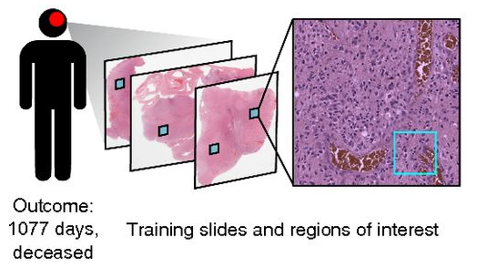

Image taken from Mobadersany et al., (2018). Predicting cancer outcomes from histology and genomics using convolutional networks. Proceedings of the National Academy of Sciences, 115(13), E2970-E2979.

#### B. Modeling EHR data for prognosis prediction

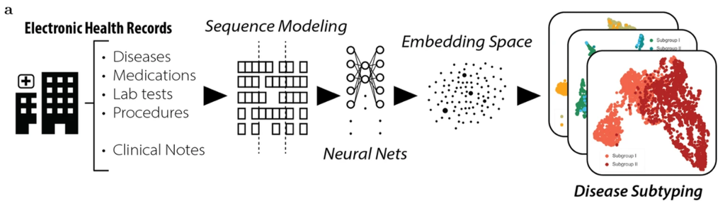

Image taken from Landi et al., (2020). Deep representation learning of electronic health records to unlock patient stratification at scale. NPJ digital medicine, 3(1), 1-11.

### Why neural networks?

1. No underlying model assumptions.
2. Less of a need for human intervention.
3. Generalizable: modular, transferrable, and customizable.

### Why not neural networks?

1. High data requirements.
2. Lack of model interpretibility.
3. Training time.

## 2. Neural network primer

We'll briefly cover essential theory to get started trarining neural nets, including:

1. Components
2. Model training
3. Model optimization

### The anatomy of a neural network

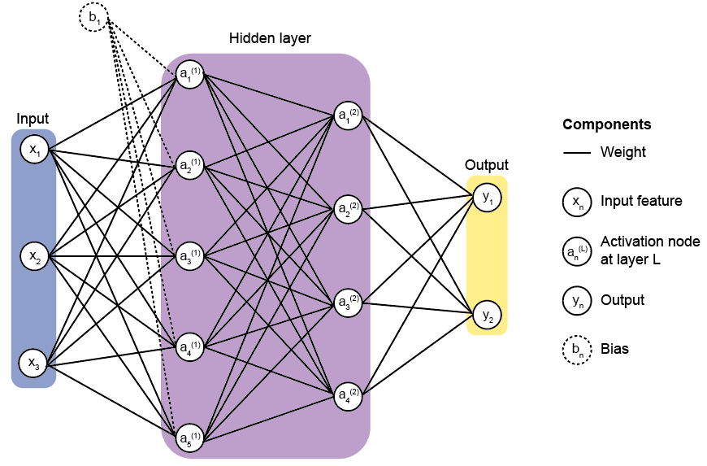

Take-home message: a neural network feeds data (input layer) into the hidden layer - a modular stack of equations that combines the data in a very non-linear way. The numbers returned in the output layer correspond to floating values (regression) or a probability of a given class (classification).

### Model training

Training a neural network requires us to iterate 3 distinct phases for n times (epochs) until we reach a stable objective value (e.g., minimize cost).

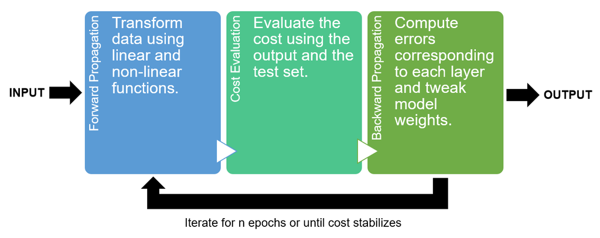

The three phases are:

1. Forward propagation
2. Solve the objective function
3. Backward propagation and weight update

#### A. Forward propagation

What is forward propagation?

Forward propagation is the process of fitting a model with weights (analagous to regression coefficients). Then we transform the data with a non-linear activation function.

One activation function is the sigmoid function. This function scales the data to assume a range of [0, 1], and is equivalent to performing logistic regression. The sigmoid distribution resulting from a normal distribution is shown below.

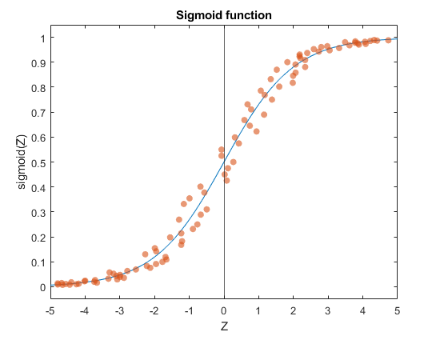

Take-home: This function is particularly useful to get probabilities for a binary classification problem.

Important note: The activation function for a multi-class classification problem is called the softmax function, and this is a generalization of the sigmoid activation function. This is the activation function we will use in the lab section of this lecture.

How is this different from traditional ML?

Fitting data to a linear equation (linear regression) or taking the sigmoid of the linear equation (logistic regression) are algorithms by their own right. However, neural networks are modular: we can stack these equations together into segments called layers.

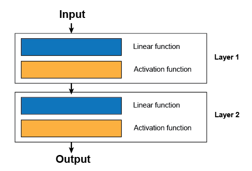

Shown in the figure above is a schematic of what goes on in a neural network layer. Each layer contains a linear function with an activation function. The training data is passed into layer 1, where it is linearly and non-linearly transformed. The resulting data computed from layer 1 is passed into layer 2, and is not seen by us. This is why this section is known as the hidden layer - we typically don't see the inner workings of the model.

#### B. Solve the objective function

Next, we need to see how right or wrong our model is by computing the objective value. In most cases, we're interested in computing the cost value. For regression, we typically use the mean-squared error. For binary classifiication, we use cross-entropy.

#### C. Backward propagation and weight update with gradient descent

What is backward propagation?

Motivation: We just computed the global model error. However, to make our model learn better weights, we need to figure out how each weight contributed to this error.

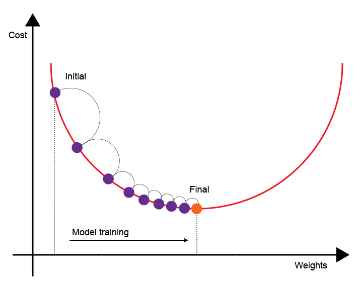

Backward propagation is the process of telling us where the errors occurred in forward propagation, starting from the cost value and working our way backwards. By computing the error contribution for each weight, we can use gradient descent to tweak individual weights to get a more accurate answer.

### Summary

We just went through one epoch of model training. In practice, we would (and we will) iterate this process several more times to get our final model.

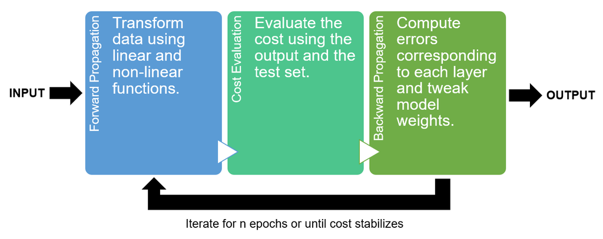

To summarize the process of training a neural network, the three phases of training involve:

1. Forward propagation: fitting the data with model weights across several layers.
2. Solve the objective function, such as the model cost.
3. Backward propagation and weight update to get a more accurate model in the next epoch.

## 3. Training shallow feedforward neural networks

To practice training neural networks, we'll train a shallow neural network: a neural network with few layers. Information is only fed into the next adjacent layer (and not back into previous layers), making this a feedforward neural network.

- This is in contrast to recurrent neural networks, where information can travel back to the previous layer. This is beyond the scope of this lecture, but you can find additional information in the appendix.

### Description of the dataset

This built-in MATLAB dataset can be called using the load cancer_dataset command, and a comprehensive description of the dataset can be found by typing in help cancer_dataset.

- The input is a matrix of 9 features from 699 biopsies. The features include attributes such as adhesion, cell size, and cell shape. These are stored in the cancerInputs variable.
- The output cancerTargets variable is a 2 x 699 matrix, where the first row corresponds to benign, and the the second row corresponds to malignant.

### A. Load the breast cancer image classification dataset

Let's load the breast cancer image classification dataset. The MATLAB built-in functions process datasets where the features/target variables span the rows, while the observations span the columns.

```matlab
clear all;
load cancer_dataset.mat

X = cancerInputs;
Y = cancerTargets;
```

#### Splitting the data into training and validation sets

The data needs to be split into a training set and validation set. To save time, we created a function called trainTestSplit that automatically does that.

The docstring is provided below:

[Xtrain, Ytrain, Xtest, Ytest] = trainTestSplit(X, Y, trainSize)

% INPUTS

% X: A numeric matrix containing the training values.

% Y: A numeric/boolean/categorical variable containing the target/response.

% trainSize: A floating value between 0 and 1 denoting the size of the training set (0.8 = 80% training/20% test)

% OUTPUTS

% Xtrain, Ytrain: Input and output training set

% Xtest, Ytest: Input and output test set

```matlab
% Initialize params for trainTestSplit
trainingSize = 0.8; randomstate = 2;

% Split the dataset into training and test sets.
[Xtrain, Ytrain, Xval, Yval] = ...
    trainTestSplit(X', Y', ...
    trainingSize, randomstate);
```

Finally, we need to reformat the data for the deep learning toolbox. Everything will be transposed, and the output for classification needs to be a categorical data type.

```matlab
% Re-format so the DLT can use the data
Xtrain = Xtrain';              Xval = Xval';
Ytrain = categorical(Ytrain'); Yval = categorical(Yval');
```

### B. Setting the shallow neural network architecture

Now, we need to specify the neural network architecture. We will store the network as an array called layers, which will contain several structures used for our downstream computations.

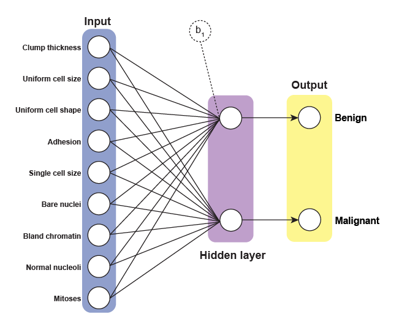

```matlab
% Specify neural network architecture
layers = [...

    sequenceInputLayer(size(X, 1)), ...          % Input data layer

    fullyConnectedLayer(10, ...                  % Hidden layer 1 with 10 nodes
    'WeightsInitializer', 'narrow-normal', ...
    'BiasInitializer', 'narrow-normal'), ...

    softmaxLayer, ...                            % Activation function

    fullyConnectedLayer(2, ...                   % Output layer with 2 nodes
    'WeightsInitializer', 'narrow-normal', ...
    'BiasInitializer', 'narrow-normal'), ...

    softmaxLayer, ...                            % Transform to probabilities

    classificationLayer ...                      % Label encode
]
```

layers =

6×1 Layer array with layers: 1 '' Sequence Input Sequence input with 9 dimensions 2 '' Fully Connected 10 fully connected layer 3 '' Softmax softmax 4 '' Fully Connected 2 fully connected layer 5 '' Softmax softmax 6 '' Classification Output crossentropyex

### C. View the network structure with MATLAB's GUI

Let's view the network structure stored in the layers variable using the analyzeNetwork function.

```matlab
analyzeNetwork(layers)
```

### D.Setting up the network hyperparameters

Hyperparameters are user-set parameters that will affect the model performance. Some examples we've seen so far are the number of nodes and number of layers in a network.

The trainingOptions function creates a model object that lets you feed in the hyperparameters into the neural network function. The specific arguments we will use are shown below, along with a description of what they do.

```matlab
% Spcify hyperparameters for neural network
options = trainingOptions(...
    'adam', ...                                   % Adam optimization
    'InitialLearnRate', 0.01, ...                 % Set the initial learning rate to 0.01
    'MaxEpochs', 200, ...                         % Maximum number of epochs to train algorithm
    'ValidationData', {Xval, Yval(1, :)}, ...     % Dataset to use as the validation set
    'ValidationFrequency', 30, ...                % Frequency to validate the network at regular intervals
    'Verbose', true, ...                          % Outputs information about training
    'Shuffle', 'every-epoch', ...                 % Data shuffling for every epoch
    'Plots', 'training-progress' ...              % Show plots for every epoch
);
```

### F. Training the shallow neural network

Finally, let's train the neural network using the trainNetwork function, which allows us to train other deep neural network architectures.

For more information on other neural networks you can train using this function, you can [read the documentation](https://www.mathworks.com/help/deeplearning/ref/trainnetwork.html).

```matlab
[snn, trainingInfo] = trainNetwork(Xtrain, Ytrain(1, :), layers, options)
```

Training on single GPU.

|======================================================================================================================| | Epoch | Iteration | Time Elapsed | Mini-batch | Validation | Mini-batch | Validation | Base Learning | | | | (hh:mm:ss) | Accuracy | Accuracy | Loss | Loss | Rate | |======================================================================================================================|

[output not shown]

| 30 | 30 | 00:00:07 | 66.55% | 61.43% | 0.5954 | 0.6218 | 0.0100 |

| 50 | 50 | 00:00:07 | 66.55% | | 0.4880 | | 0.0100 |

| 60 | 60 | 00:00:07 | 90.88% | 90.71% | 0.4158 | 0.4270 | 0.0100 |

| 90 | 90 | 00:00:08 | 96.60% | 96.43% | 0.2377 | 0.2419 | 0.0100 |

| 100 | 100 | 00:00:09 | 96.60% | | 0.2065 | | 0.0100 |

| 120 | 120 | 00:00:09 | 96.96% | 96.43% | 0.1669 | 0.1669 | 0.0100 |

| 150 | 150 | 00:00:10 | 96.96% | 96.43% | 0.1355 | 0.1327 | 0.0100 |

| 180 | 180 | 00:00:10 | 97.14% | 96.43% | 0.1190 | 0.1142 | 0.0100 |

| 200 | 200 | 00:00:11 | 97.14% | 96.43% | 0.1120 | 0.1064 | 0.0100 |

|======================================================================================================================|

snn =

SeriesNetwork with properties: Layers: [6×1 nnet.cnn.layer.Layer] InputNames: {'sequenceinput'} OutputNames: {'classoutput'}

trainingInfo = struct with fields:

TrainingLoss: [1×200 double] TrainingAccuracy: [1×200 double] ValidationLoss: [1×200 double] ValidationAccuracy: [1×200 double] BaseLearnRate: [1×200 double] FinalValidationLoss: 0.1064 FinalValidationAccuracy: 96.4286

A window will pop up with the following plot as the model is trained in real time.

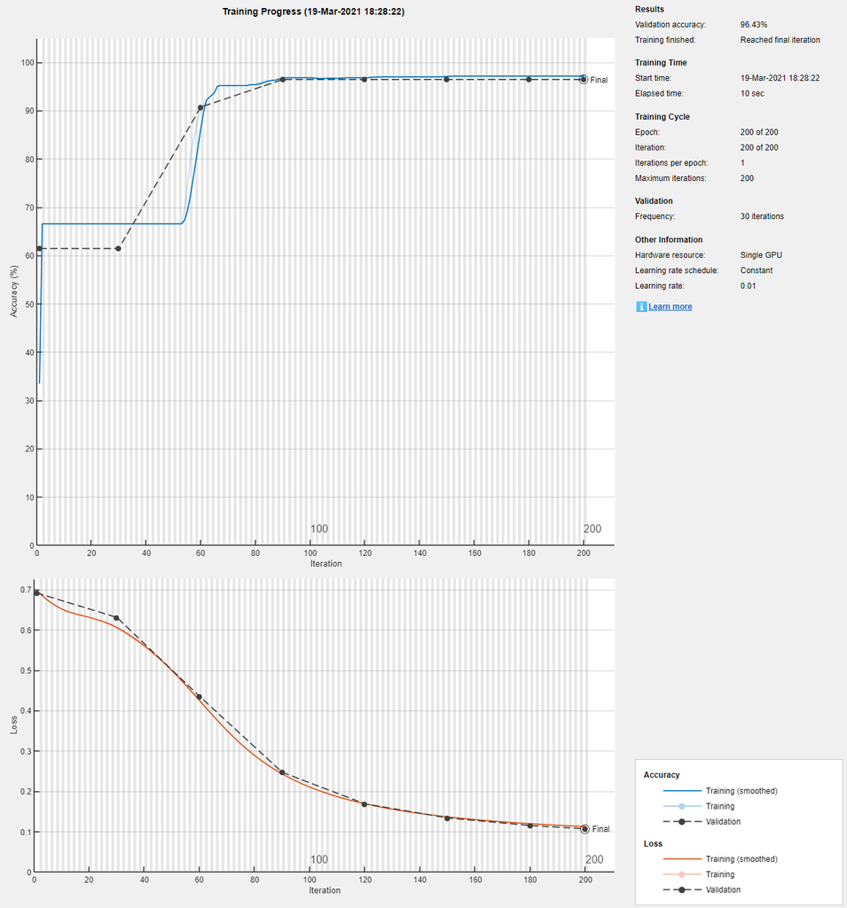

### G. Computing model predictions and evaluating model performance

```matlab
ypred_snn = classify(snn, Xval)
```

ypred_snn = 1×140 categorical

0 0 1 0 1 1 0 0 1 1 0 0 1 0 0 1 1 0 0 1 0 0 0 1 1 1 0 1 0 0

### H. Plotting model metrics

#### Confusion matrix

To evaluate the average and individual class accuracies, we can use a confusion matrix.

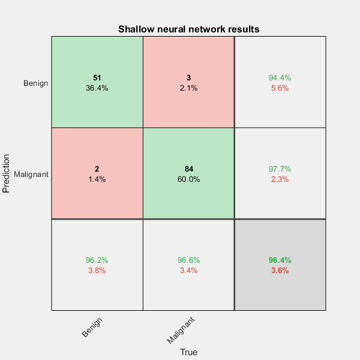

```matlab
figure;
plotconfusion(ypred_snn, Yval(1, :));
title("Shallow neural network results");
xlabel("True"); ylabel("Prediction");
xticklabels(["Benign", "Malignant"]);
yticklabels(["Benign", "Malignant"]);
```

## 4. Training deep feedforward neural networks

We'll train a deep neural network: a neural network with many layers.

A general trend with deep neural networks is that the more nodes and more layers you add, the more accurate the model becomes. However, tradeoff is that this increases the computation time and the risk of overfitting.

### A. Declare the model architecture

Now, we need to specify the neural network architecture. We will store the network as an array called layers. We'll be constructing a deep neural network that has the following structure:

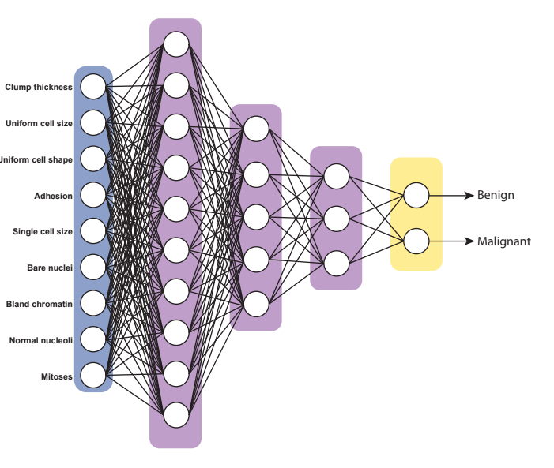

Create the layers structure.

```matlab
% Specify neural network architecture
layers = [...

    sequenceInputLayer(size(X, 1)), ...            % Input data layer

    fullyConnectedLayer(10, ...                    % Hidden layer 1 with 10 nodes
    'WeightsInitializer', 'narrow-normal', ...
    'BiasInitializer', 'narrow-normal'), ...

    softmaxLayer, ...                              % Activation function 1

    fullyConnectedLayer(5, ...                     % Hidden layer 2 with 5 nodes
    'WeightsInitializer', 'narrow-normal', ...
    'BiasInitializer', 'narrow-normal'), ...

    softmaxLayer, ...                              % Activation function 2

    fullyConnectedLayer(3, ...                     % Hidden layer 3 with 3 nodes
    'WeightsInitializer', 'narrow-normal', ...
    'BiasInitializer', 'narrow-normal'), ...

    softmaxLayer, ...                              % Activation function 3

    fullyConnectedLayer(2, ...                     % Output layer with 2 nodes
    'WeightsInitializer', 'narrow-normal', ...
    'BiasInitializer', 'narrow-normal'), ...

    softmaxLayer, ...                              % Transform to probabilities

    classificationLayer ...                        % Label encode
]
```

### B.Setting up the network hyperparameters

Next, we have to specify the model hyperparameters. We'll use the same hyperparameters we previously specified.

```matlab
% Spcify hyperparameters for neural network
options = trainingOptions(...
    'adam', ...                                   % Adam optimization
    'InitialLearnRate', 0.01, ...                 % Set the initial learning rate to 0.01
    'MaxEpochs', 200, ...                         % Maximum number of epochs to train algorithm
    'ValidationData', {Xval, Yval(1, :)}, ...     % Dataset to use as the validation set
    'ValidationFrequency', 30, ...                % Frequency to validate the network at regular intervals
    'Verbose', true, ...                          % Outputs information about training
    'Shuffle', 'every-epoch', ...                 % Data shuffling for every epoch
    'Plots', 'training-progress' ...              % Show plots for every epoch
);
```

### C. Training the deep neural network

Finally, let's train the neural network using the trainNetwork function.

```matlab
[dnn, trainingInfo] = trainNetwork(Xtrain, Ytrain(1, :), layers, options)
```

Training on single GPU.

|======================================================================================================================| | Epoch | Iteration | Time Elapsed | Mini-batch | Validation | Mini-batch | Validation | Base Learning | | | | (hh:mm:ss) | Accuracy | Accuracy | Loss | Loss | Rate | |======================================================================================================================|

| 1 | 1 | 00:00:05 | 33.45% | 61.43% | 0.6955 | 0.6902 | 0.0100 |

| 30 | 30 | 00:00:06 | 66.55% | 61.43% | 0.5887 | 0.6132 | 0.0100 |

| 50 | 50 | 00:00:07 | 73.17% | | 0.4654 | | 0.0100 |

| 60 | 60 | 00:00:07 | 93.38% | 91.43% | 0.3892 | 0.3993 | 0.0100 |

| 90 | 90 | 00:00:08 | 96.60% | 96.43% | 0.2365 | 0.2413 | 0.0100 |

| 100 | 100 | 00:00:08 | 96.78% | | 0.2087 | | 0.0100 |

| 120 | 120 | 00:00:08 | 96.96% | 97.14% | 0.1712 | 0.1722 | 0.0100 |

| 150 | 150 | 00:00:09 | 96.96% | 96.43% | 0.1398 | 0.1379 | 0.0100 |

| 180 | 180 | 00:00:09 | 97.14% | 96.43% | 0.1225 | 0.1187 | 0.0100 |

| 200 | 200 | 00:00:10 | 97.14% | 97.14% | 0.1150 | 0.1103 | 0.0100 |

|======================================================================================================================|

dnn =

trainingInfo = struct with fields:

TrainingLoss: [1×200 double] TrainingAccuracy: [1×200 double] ValidationLoss: [1×200 double] ValidationAccuracy: [1×200 double] BaseLearnRate: [1×200 double] FinalValidationLoss: 0.1103 FinalValidationAccuracy: 97.1429

### D. Computing model predictions and evaluating model performance

```matlab
ypred_dnn = classify(dnn, Xval)
```

ypred_dnn = 1×140 categorical

0 0 1 0 1 1 0 0 1 1 0 0 1 0 0 1 1 0 0 1 0 0 0 1 1 1 0 1 0 0

### E. Plotting model metrics

#### Confusion matrix

To evaluate the average and individual class accuracies, we can use a confusion matrix.

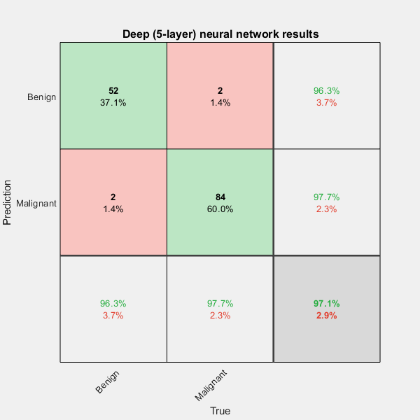

```matlab
figure;
plotconfusion(ypred_dnn, Yval(1, :));
title("Deep (5-layer) neural network results");
xlabel("True"); ylabel("Prediction");
xticklabels(["Benign", "Malignant"]);
yticklabels(["Benign", "Malignant"]);
```

## 5. Model optimization

While neural networks are really popular for artificial intelligence research and applications, they can be difficult to train and computationally intensive. We'll discuss common issues encountered when training neural network and potential strategies to address these issues.

### A. Regularization

MATLAB's Deep Learning Toolbox currently only supports L2 (Ridge) regularization as a built-in function using the trainingOptions object. To specify the tuning parameter to be 1E-5, we can use the following syntax:

% Implementing Ridge regularization using the Deep Learning Toolbox

options = trainingOptions( ...

'L2Regularization', 1E-5);

net = trainNetwork(Xtrain, Ytrain, layers, options);

### B. Dropout

Overfitting is a result of a model fitting to noise in the dataset, rather than the real signal. Instead of constraining the model, [Srivastava et al., 2014](https://www.cs.toronto.edu/~hinton/absps/JMLRdropout.pdf) suggested to do something pretty clever: randomly and temporarily remove activation nodes in the hidden layer (essentially, set it to 0 for a given epoch), along with the incoming and outgoing weights.

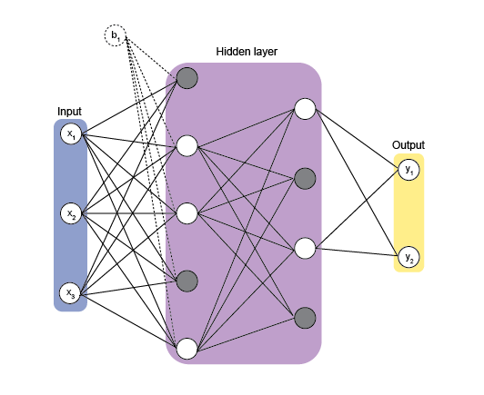

This is another form of regularization, in that the model is pruned during every epoch. It works because during the pruning process, we eliminate relationships between nodes that may be co-dependent, and causing errors in the model by random chance. By making the model more sparse, it learns the more important weights better, and increases its robustness.

To add dropout layers in the model built from the trainNetwork function, we can specify this as a dropoutLayer object when building our layers array:

layers = [...

sequenceInputLayer(size(Xtrain, 1)), ... % Input data layer

fullyConnectedLayer(100, ... % Hidden layer 1 with 100 nodes

'WeightsInitializer', 'narrow-normal', ...

'BiasInitializer', 'narrow-normal'), ...

reluLayer, ... % ReLU activation function

dropoutLayer, ... % Dropout layer

fullyConnectedLayer(100, ... % Hidden layer 2 with 100 nodes

'WeightsInitializer', 'narrow-normal', ...

'BiasInitializer', 'narrow-normal'), ...

softmaxLayer, ... % Softmax activation function

classificationLayer ... % Perform classification

]

### C. Parallel computing

#### Multiple CPUs

When working with really large datasets, computational efficiency becomes more important. One way to deal with more complex models or computing large datasets for any model is to run MATLAB with the [Parallel Computing Toolbox](https://www.mathworks.com/products/parallel-computing.html#scale-up-matlab-applications), which splits the computation process between different processing units if you have a multi-core machine.

To implement parallel processing with a shallow neural network, we can use the following snippet of code to use the parallel computing toolbox.

parpool % Set a parallel pool of workers

net = feedforwardnet(2); % Train a feedforward neural network with 2 activation nodes in 1 hidden layer

trainedNetwork = train(net, Xtrain, Ytrain, ... % Train the neural network with parallel workers

'useParallel', 'yes', ...

'showResources', 'yes');

#### D. Training with a GPU

The Parallel Computing Toolbox also allows us to run our code on a GPU if your local machine or computing cluster if available.

Currently MATLAB only supports NVIDIA GPUs. To train a deep neural network using a GPU, MATLAB automatically detects and uses the gpu from the ExecutationEnvironment argument.

However, if we want to use both the gpu and cpu, we can specify this argument to parallel.

parpool % Set a parallel pool of workers

net = feedforwardnet(2); % Train a feedforward neural network with 2 activation nodes in 1 hidden layer

trainedNetwork = train(net, Xtrain, Ytrain, ... % Train the neural network with parallel workers

'useParallel', 'yes', ... % If this is specified, 1 worker will use the GPU while the remainder will use CPU cores

'showResources', 'yes', ...

'useGPU', 'yes'); % Only specify if you have a GPU

Alternatively, we can specify which datasets we want to be fed into a GPU computation using the gpuArray function. If you do have a GPU, these arrays will automatically be detected for GPU use.

Xtrain = gpuArray(Xtrain);

Ytrain = gpuArray(Ytrain);

net = configure(net, Xtrain, Ytrain)

trainedNetwork = train(net, Xtrain, Ytrain)

Finally, if we want to use the trainNetwork function to train a deep neural network using a GPU, we can specify the GPU as a hyperparameter in the function.

% Set training options for the trainNetwork function to use both cpu and gpu

options = trainingOptions('ExecutionEnvironment', 'parallel')

## Summary

We have covered strategies to prevent model overfitting, systematic ways to tune hyperparameters, and ways to utilize our hardware for more efficient neural network training.

## Appendix

### Built in MATLAB functions covered in this lesson

analyzeNetwork: View the network structure.

sequenceInputLayer: Create an input dataset structure.

fullyConnectedLayer: Create an object that does a linear transformation.

softmaxLayer: Create an object that does a sigmoid transformation.

classificationLayer: Create an object that performs classification.

trainingOptions: Create an object that stores model hyperparameters.

trainNetwork: Train the neural network.

classify: Perform a classification prediction with a trained neural network.

plotconfusion: Plot a confusion matrix.

### List of custom functions

trainTestSplit: Splits an input (X) and output (Y) dataset into a training and testing dataset.

### Useful reading and references

- A [generalized tutorial for learning about neural networks](https://medium.com/datathings/neural-networks-and-backpropagation-explained-in-a-simple-way-f540a3611f5e) that is language-agnostic.
- The [various flavors of neural networks](https://towardsdatascience.com/the-mostly-complete-chart-of-neural-networks-explained-3fb6f2367464), and how they are currently being used in real-world settings.
- Heuristics on deciding [how many hidden layers and activation nodes](https://machinelearningmastery.com/how-to-configure-the-number-of-layers-and-nodes-in-a-neural-network/) to initialize in a neural network.
- [Other activation functions, their usage, and generalizations about pros/cons](https://medium.com/@himanshuxd/activation-functions-sigmoid-relu-leaky-relu-and-softmax-basics-for-neural-networks-and-deep-8d9c70eed91e).
- The [deep learning specialization on Coursera](https://www.coursera.org/specializations/deep-learning) (also taught by Andrew Ng and others at [deeplearning.ai](https://www.deeplearning.ai/)). It consists of 5 courses, all on deep learning and optimizing these models. The course is taught in Python with the specific usage of the numpy and scipy libraries.
- [Deep Learning](http://www.deeplearningbook.org/) by Ian Goodfellow and Yoshua Bengio - two pioneers in modern deep learning. The book is technical and dives deep into the theory. Recommended for intermediate to advanced level understanding.